# housing

## Grade

```
(-0.5, 11.5, -3.9001486186158347, 5.772883452065583)
```

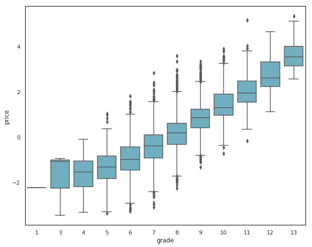

```python
sns.set(style="white")
f, ax = plt.subplots(figsize=(10, 8))
fig = sns.boxplot(x='grade', y="price", data=house, color="c")
fig.axis()
```

Very clearly shown, the prices increase with grade.

## Lat,Long and Zipcode

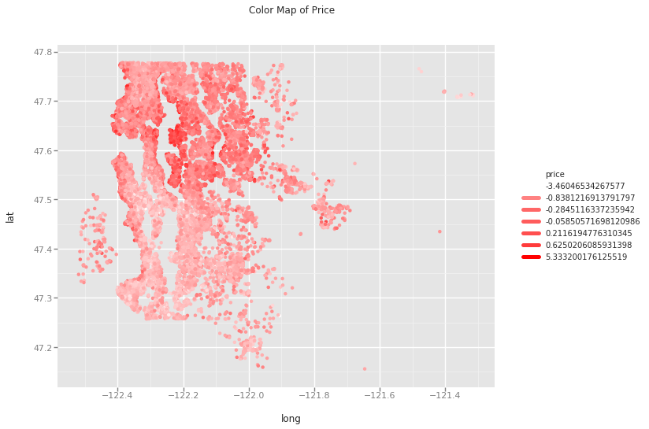

```python
from ggplot import *
lonlat = ggplot(house,aes(x='long',y='lat',color='price'))+geom_point()+scale_color_gradient(low='white',high='red')+ggtitle('Color Map of Price')
print(lonlat)
```

As shown in the plot, the more expensive houses tends to be concentrated at certain locations and these locations can be partially represented by their zipcodes.

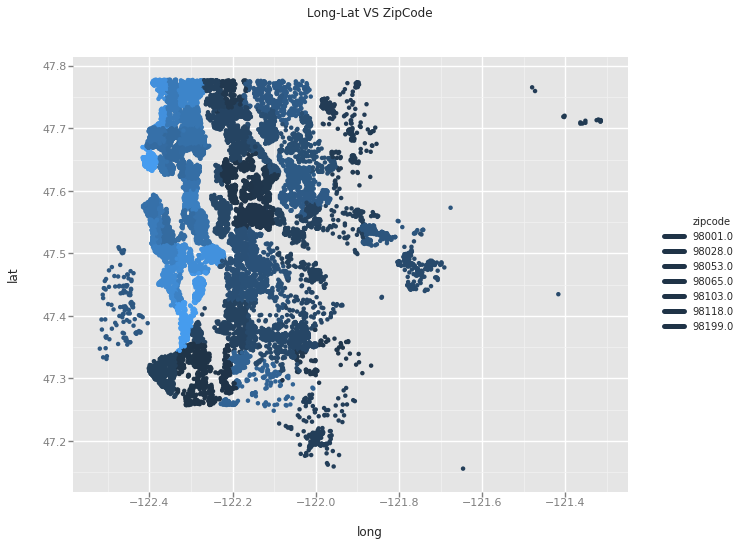

```python
latlonzip = ggplot(house,aes(x='long',y='lat',color='zipcode'))+geom_point()+ggtitle('Long-Lat VS ZipCode')
print(latlonzip)
```

```python
# The latitude and longtitude is already represented by the zipcode and we can see that the location of the house has a big say in its price
# So I will drop the longtitude and latitude and keep the zipcode.
```

## yr_renovated

```
(1920, 2018)
```

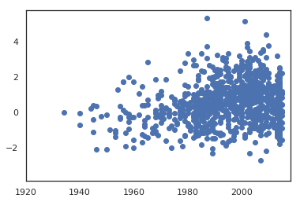

```python
plt.scatter(house.yr_renovated, house.price)
plt.xlim(1920,2018)
```

```python
#The year of renovation doesnt seem to have much impact on price. We notice that some houses last renovated in the 1930s
#and 1940s are worth more than other house renovated around 2015. We will drop the column.
```

## Date

```python
#The format of the date has some trouble, I will drop the date and derive the year sold and age of the house from the date
house['year_sold'] = house['date'].apply(lambda x: int(x[:4]))
house['age'] = house[['year_sold']].sub(house['yr_built'], axis=0)
```

## Everything else

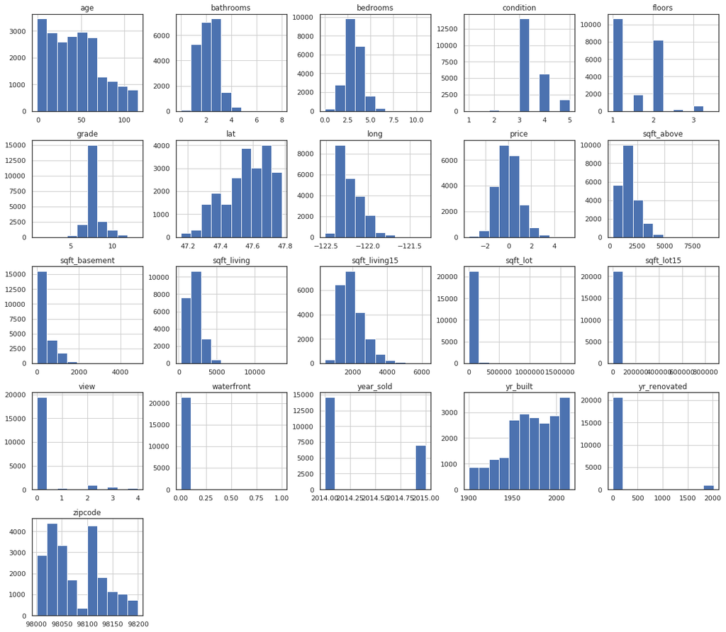

```python
#just to check the spread of each feature
house.hist(figsize = (20,18));
```

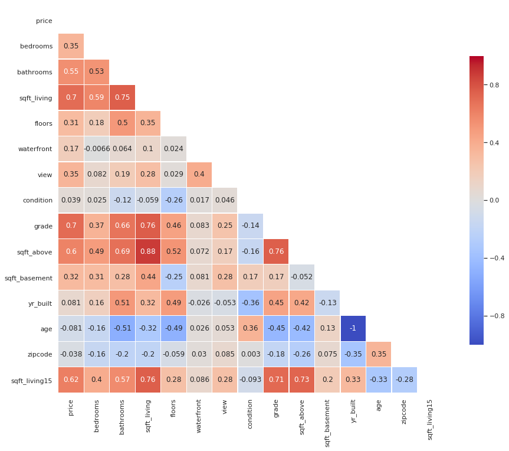

```python
features = ['price','bedrooms','bathrooms','sqft_living','floors',
            'waterfront','view','condition','grade','sqft_above','sqft_basement',
            'yr_built','age','zipcode','sqft_living15']

mask = np.zeros_like(house[features].corr(), dtype=np.bool)
mask[np.triu_indices_from(mask)] = True

f, ax = plt.subplots(figsize=(16, 12))

sns.heatmap(house[features].corr(),linewidths=0.25,vmax=1.0,square=True,cmap="coolwarm",
            linecolor='w',annot=True,mask=mask,cbar_kws={"shrink": .75});
```

The heatmap shows clear correlation between the various living spaces and various rooms. Noticeably, grade is a pretty good indicator of both price and space

# Data preparation

```python
#Check again for the new set of columns after data exploration
house.info()
```

```
<class 'pandas.core.frame.DataFrame'>
Int64Index: 21612 entries, 0 to 21612
Data columns (total 22 columns):
date             21612 non-null object
price            21612 non-null float64
bedrooms         21612 non-null int64
bathrooms        21612 non-null float64
sqft_living      21612 non-null int64
sqft_lot         21612 non-null int64
floors           21612 non-null float64
waterfront       21612 non-null int64
view             21612 non-null int64
condition        21612 non-null int64
grade            21612 non-null int64
sqft_above       21612 non-null int64
sqft_basement    21612 non-null int64
yr_built         21612 non-null int64
yr_renovated     21612 non-null int64
zipcode          21612 non-null int64
lat              21612 non-null float64
long             21612 non-null float64
sqft_living15    21612 non-null int64
sqft_lot15       21612 non-null int64
year_sold        21612 non-null int64
age              21612 non-null int64
dtypes: float64(5), int64(16), object(1)
memory usage: 4.4+ MB
```

## Categorical Data

```python
# convert categorical data to "category" type
house.floors = house.floors.astype('category')
house.zipcode = house.zipcode.astype('category')
house.condition = house.condition.astype('category')
house.view = house.view.astype('category')
house.bedrooms = house.bedrooms.astype('category')
house.grade =house.grade.astype('category')
house.bathrooms = house.bathrooms.astype('category')
house.waterfront=house.waterfront.astype('category')
```

## Drop data

```python
#house = house.drop('sqft_lot', 1)
#house = house.drop('sqft_lot15', 1)
#house = house.drop('lat', 1)
#house = house.drop('long', 1)
#house = house.drop('yr_renovated', 1)
house = house.drop('date', 1)
```

I realise that droping the data would negatively impact my r2 score hence I decided to keep them.

## test-train split

```python
from sklearn.model_selection import train_test_split
y = house["price"].values
X = house.drop(["price"],axis=1).values

X_train, X_test, y_train, y_test = train_test_split(X, y, test_size=0.20)
```

# Train Model

## Stupid baseline - DummyRegressor

```python
#bulid a stupid baseline of predicting the mean price of the house for everyhouse.
dummy = DummyRegressor(strategy='mean')
dummy.fit(X_train, y_train)
pred1 = dummy.predict(X_train)
pred2 = dummy.predict(X_test)
amse_dummy = format(np.sqrt(mean_squared_error(y_train,pred1)),'.3f')
bmse_dummy = format(np.sqrt(mean_squared_error(y_test,pred2)),'.3f')
ar2_dummy = format(r2_score(y_train,pred1),'.3f')
br2_dummy = format(r2_score(y_test,pred2),'.3f')
```

## KNeighbors Regressor

```python
knnreg = KNeighborsRegressor(n_neighbors=15)
knnreg.fit(X_train,y_train)
pred1 = knnreg.predict(X_train)
pred2 = knnreg.predict(X_test)
amse_knn = format(np.sqrt(mean_squared_error(y_train,pred1)),'.3f')
bmse_knn = format(np.sqrt(mean_squared_error(y_test,pred2)),'.3f')
ar2_knn = format(r2_score(y_train,pred1),'.3f')
br2_knn = format(r2_score(y_test,pred2),'.3f')
```

## Linear Regression

```python
lr = LinearRegression()
lr.fit(X_train,y_train)
pred1 = lr.predict(X_train)
pred2 = lr.predict(X_test)
amse_lr = format(np.sqrt(mean_squared_error(y_train,pred1)),'.3f')
bmse_lr = format(np.sqrt(mean_squared_error(y_test,pred2)),'.3f')
ar2_lr = format(r2_score(y_train,pred1),'.3f')
br2_lr = format(r2_score(y_test,pred2),'.3f')
```

## Elastic NetCV

```python
ENSTest = linear_model.ElasticNetCV()
ENSTest.fit(X_train, y_train)
pred1 = ENSTest.predict(X_train)
pred2 = ENSTest.predict(X_test)
amse_ENSTest = format(np.sqrt(mean_squared_error(y_train,pred1)),'.3f')
bmse_ENSTest = format(np.sqrt(mean_squared_error(y_test,pred2)),'.3f')
ar2_ENSTest = format(r2_score(y_train,pred1),'.3f')
br2_ENSTest = format(r2_score(y_test,pred2),'.3f')
```

## RandomForest Regressor

```python
RF= RandomForestRegressor()
RF.fit(X_train, y_train)
pred1 = RF.predict(X_train)
pred2 = RF.predict(X_test)
amse_RF = format(np.sqrt(mean_squared_error(y_train,pred1)),'.3f')
bmse_RF = format(np.sqrt(mean_squared_error(y_test,pred2)),'.3f')
ar2_RF = format(r2_score(y_train,pred1),'.3f')
br2_RF = format(r2_score(y_test,pred2),'.3f')
```

## Gradient Boosting Regressor

```python
GBest = GradientBoostingRegressor()
GBest.fit(X_train,y_train)
pred1 = GBest.predict(X_train)
pred2 = GBest.predict(X_test)
amse_GBest = format(np.sqrt(mean_squared_error(y_train,pred1)),'.3f')
bmse_GBest = format(np.sqrt(mean_squared_error(y_test,pred2)),'.3f')
ar2_GBest = format(r2_score(y_train,pred1),'.3f')
br2_GBest = format(r2_score(y_test,pred2),'.3f')
```